# Risk Factor Analysis

## Outcome Variable

**Outcome Variable:** haz

## Predictor Variables

**Intervention Variable:** anywast06

**Adjustment Set:**

- arm
- sex
- brthmon
- W_mage
- meducyrs
- hhwealth_quart
- W_nrooms
- month
- W_parity
- delta_W_mage
- delta_meducyrs
- delta_hhwealth_quart
- delta_W_nrooms
- delta_month
- delta_W_parity

## Stratifying Variables

The analysis was stratified on these variable(s):

- agecat
- studyid
- country

## Data Summary

| agecat | studyid | country | anywast06 | n_cell | n | outcome_variable |
| --- | --- | --- | --- | --- | --- | --- |
| Birth | ki0047075b-MAL-ED | BANGLADESH | 0 | 177 | 229 | haz |
| Birth | ki0047075b-MAL-ED | BANGLADESH | 1 | 52 | 229 | haz |
| Birth | ki0047075b-MAL-ED | BRAZIL | 0 | 62 | 65 | haz |
| Birth | ki0047075b-MAL-ED | BRAZIL | 1 | 3 | 65 | haz |
| Birth | ki0047075b-MAL-ED | INDIA | 0 | 33 | 47 | haz |
| Birth | ki0047075b-MAL-ED | INDIA | 1 | 14 | 47 | haz |
| Birth | ki0047075b-MAL-ED | NEPAL | 0 | 23 | 27 | haz |
| Birth | ki0047075b-MAL-ED | NEPAL | 1 | 4 | 27 | haz |
| Birth | ki0047075b-MAL-ED | PERU | 0 | 223 | 233 | haz |
| Birth | ki0047075b-MAL-ED | PERU | 1 | 10 | 233 | haz |
| Birth | ki0047075b-MAL-ED | SOUTH AFRICA | 0 | 101 | 122 | haz |
| Birth | ki0047075b-MAL-ED | SOUTH AFRICA | 1 | 21 | 122 | haz |
| Birth | ki0047075b-MAL-ED | TANZANIA, UNITED REPUBLIC OF | 0 | 119 | 124 | haz |
| Birth | ki0047075b-MAL-ED | TANZANIA, UNITED REPUBLIC OF | 1 | 5 | 124 | haz |
| Birth | ki1000108-CMC-V-BCS-2002 | INDIA | 0 | 37 | 92 | haz |
| Birth | ki1000108-CMC-V-BCS-2002 | INDIA | 1 | 55 | 92 | haz |
| Birth | ki1000108-IRC | INDIA | 0 | 164 | 388 | haz |
| Birth | ki1000108-IRC | INDIA | 1 | 224 | 388 | haz |
| Birth | ki1000109-EE | PAKISTAN | 0 | 156 | 240 | haz |
| Birth | ki1000109-EE | PAKISTAN | 1 | 84 | 240 | haz |
| Birth | ki1000109-ResPak | PAKISTAN | 0 | 28 | 42 | haz |
| Birth | ki1000109-ResPak | PAKISTAN | 1 | 14 | 42 | haz |
| Birth | ki1017093b-PROVIDE | BANGLADESH | 0 | 396 | 539 | haz |
| Birth | ki1017093b-PROVIDE | BANGLADESH | 1 | 143 | 539 | haz |
| Birth | ki1101329-Keneba | GAMBIA | 0 | 994 | 1542 | haz |
| Birth | ki1101329-Keneba | GAMBIA | 1 | 548 | 1542 | haz |
| Birth | ki1113344-GMS-Nepal | NEPAL | 0 | 422 | 684 | haz |
| Birth | ki1113344-GMS-Nepal | NEPAL | 1 | 262 | 684 | haz |
| Birth | ki1114097-CMIN | BANGLADESH | 0 | 15 | 20 | haz |
| Birth | ki1114097-CMIN | BANGLADESH | 1 | 5 | 20 | haz |

[output cut: 70 more lines]

The following strata were considered:

- agecat: 24 months, studyid: ki0047075b-MAL-ED, country: BANGLADESH
- agecat: 24 months, studyid: ki0047075b-MAL-ED, country: BRAZIL
- agecat: 24 months, studyid: ki0047075b-MAL-ED, country: INDIA
- agecat: 24 months, studyid: ki0047075b-MAL-ED, country: NEPAL
- agecat: 24 months, studyid: ki0047075b-MAL-ED, country: PERU
- agecat: 24 months, studyid: ki0047075b-MAL-ED, country: SOUTH AFRICA
- agecat: 24 months, studyid: ki0047075b-MAL-ED, country: TANZANIA, UNITED REPUBLIC OF
- agecat: 24 months, studyid: ki1000108-CMC-V-BCS-2002, country: INDIA
- agecat: 24 months, studyid: ki1000108-IRC, country: INDIA
- agecat: 24 months, studyid: ki1000109-EE, country: PAKISTAN
- agecat: 24 months, studyid: ki1017093b-PROVIDE, country: BANGLADESH
- agecat: 24 months, studyid: ki1066203-TanzaniaChild2, country: TANZANIA, UNITED REPUBLIC OF
- agecat: 24 months, studyid: ki1101329-Keneba, country: GAMBIA
- agecat: 24 months, studyid: ki1113344-GMS-Nepal, country: NEPAL
- agecat: 24 months, studyid: ki1114097-CMIN, country: BANGLADESH
- agecat: 24 months, studyid: ki1114097-CONTENT, country: PERU
- agecat: 6 months, studyid: ki0047075b-MAL-ED, country: BANGLADESH
- agecat: 6 months, studyid: ki0047075b-MAL-ED, country: BRAZIL
- agecat: 6 months, studyid: ki0047075b-MAL-ED, country: INDIA
- agecat: 6 months, studyid: ki0047075b-MAL-ED, country: NEPAL
- agecat: 6 months, studyid: ki0047075b-MAL-ED, country: PERU
- agecat: 6 months, studyid: ki0047075b-MAL-ED, country: SOUTH AFRICA
- agecat: 6 months, studyid: ki0047075b-MAL-ED, country: TANZANIA, UNITED REPUBLIC OF
- agecat: 6 months, studyid: ki1000108-CMC-V-BCS-2002, country: INDIA
- agecat: 6 months, studyid: ki1000108-IRC, country: INDIA
- agecat: 6 months, studyid: ki1000109-EE, country: PAKISTAN
- agecat: 6 months, studyid: ki1000109-ResPak, country: PAKISTAN
- agecat: 6 months, studyid: ki1017093b-PROVIDE, country: BANGLADESH
- agecat: 6 months, studyid: ki1066203-TanzaniaChild2, country: TANZANIA, UNITED REPUBLIC OF
- agecat: 6 months, studyid: ki1101329-Keneba, country: GAMBIA
- agecat: 6 months, studyid: ki1112895-Guatemala BSC, country: GUATEMALA
- agecat: 6 months, studyid: ki1113344-GMS-Nepal, country: NEPAL
- agecat: 6 months, studyid: ki1114097-CMIN, country: BANGLADESH
- agecat: 6 months, studyid: ki1114097-CONTENT, country: PERU
- agecat: Birth, studyid: ki0047075b-MAL-ED, country: BANGLADESH
- agecat: Birth, studyid: ki0047075b-MAL-ED, country: BRAZIL
- agecat: Birth, studyid: ki0047075b-MAL-ED, country: INDIA
- agecat: Birth, studyid: ki0047075b-MAL-ED, country: NEPAL
- agecat: Birth, studyid: ki0047075b-MAL-ED, country: PERU
- agecat: Birth, studyid: ki0047075b-MAL-ED, country: SOUTH AFRICA
- agecat: Birth, studyid: ki0047075b-MAL-ED, country: TANZANIA, UNITED REPUBLIC OF
- agecat: Birth, studyid: ki1000108-CMC-V-BCS-2002, country: INDIA
- agecat: Birth, studyid: ki1000108-IRC, country: INDIA
- agecat: Birth, studyid: ki1000109-EE, country: PAKISTAN
- agecat: Birth, studyid: ki1000109-ResPak, country: PAKISTAN
- agecat: Birth, studyid: ki1017093b-PROVIDE, country: BANGLADESH
- agecat: Birth, studyid: ki1101329-Keneba, country: GAMBIA
- agecat: Birth, studyid: ki1113344-GMS-Nepal, country: NEPAL
- agecat: Birth, studyid: ki1114097-CMIN, country: BANGLADESH
- agecat: Birth, studyid: ki1114097-CONTENT, country: PERU

### Dropped Strata

Some strata were dropped due to rare outcomes:

- agecat: Birth, studyid: ki0047075b-MAL-ED, country: BRAZIL
- agecat: Birth, studyid: ki0047075b-MAL-ED, country: NEPAL
- agecat: Birth, studyid: ki1114097-CONTENT, country: PERU
- agecat: 6 months, studyid: ki1114097-CONTENT, country: PERU
- agecat: 24 months, studyid: ki1066203-TanzaniaChild2, country: TANZANIA, UNITED REPUBLIC OF
- agecat: 24 months, studyid: ki1114097-CONTENT, country: PERU

## Methods Detail

We’re interested in the causal parameters $E[Y_a]$ for all values of $a \in \mathcal{A}$. These parameters represent the mean outcome if, possibly contrary to fact, we intervened to set all units to have $A=a$. Under the randomization and positivity assumptions, these are identified by the statistical parameters $\psi_a=E_W[E_{Y|A,W}(Y|A=a,W)]$. In addition, we’re interested in the mean of $Y$, $E[Y]$ under no intervention (the observed mean). We will estimate these parameters by using SuperLearner to fit the relevant likelihood factors – $E_{Y|A,W}(Y|A=a,W)$ and $p(A=a|W)$, and then updating our likelihood fit using a joint TMLE.

For unadjusted analyses ($W=\{\}$), initial likelihoods were estimated using Lrnr_glm to estimate the simple $E(Y|A)$ and Lrnr_mean to estimate $p(A)$. For adjusted analyses, a small library containing Lrnr_glmnet, Lrnr_xgboost, and Lrnr_mean was used.

Having estimated these parameters, we will then use the delta method to estimate relative risks and attributable risks relative to a prespecified baseline level of $A$.

# Results Detail

## Results Plots

[figure not shown]

[figure not shown]

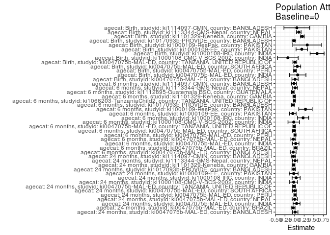

## Results Table

### Parameter: TSM

| agecat | studyid | country | intervention_level | baseline_level | estimate | ci_lower | ci_upper |
| --- | --- | --- | --- | --- | --- | --- | --- |
| Birth | ki0047075b-MAL-ED | BANGLADESH | 0 | NA | -1.1152588 | -1.2644413 | -0.9660762 |
| Birth | ki0047075b-MAL-ED | BANGLADESH | 1 | NA | -1.0741177 | -1.3882277 | -0.7600077 |
| Birth | ki0047075b-MAL-ED | INDIA | 0 | NA | -1.2832343 | -1.6079905 | -0.9584781 |
| Birth | ki0047075b-MAL-ED | INDIA | 1 | NA | -1.0231967 | -1.6629892 | -0.3834041 |
| Birth | ki0047075b-MAL-ED | PERU | 0 | NA | -0.8920237 | -1.0091922 | -0.7748552 |
| Birth | ki0047075b-MAL-ED | PERU | 1 | NA | -0.6825491 | -1.5842861 | 0.2191878 |
| Birth | ki0047075b-MAL-ED | SOUTH AFRICA | 0 | NA | -0.6578326 | -0.8440564 | -0.4716088 |
| Birth | ki0047075b-MAL-ED | SOUTH AFRICA | 1 | NA | -0.0806032 | -0.5577990 | 0.3965927 |
| Birth | ki0047075b-MAL-ED | TANZANIA, UNITED REPUBLIC OF | 0 | NA | -1.1432773 | -1.3541075 | -0.9324471 |
| Birth | ki0047075b-MAL-ED | TANZANIA, UNITED REPUBLIC OF | 1 | NA | -0.9860000 | -2.2167588 | 0.2447588 |
| Birth | ki1000108-CMC-V-BCS-2002 | INDIA | 0 | NA | -0.7863141 | -1.1163551 | -0.4562730 |
| Birth | ki1000108-CMC-V-BCS-2002 | INDIA | 1 | NA | -1.0720035 | -1.3593526 | -0.7846545 |
| Birth | ki1000108-IRC | INDIA | 0 | NA | -0.8932810 | -1.1035337 | -0.6830284 |
| Birth | ki1000108-IRC | INDIA | 1 | NA | 0.1074351 | -0.1092583 | 0.3241285 |
| Birth | ki1000109-EE | PAKISTAN | 0 | NA | -2.0471739 | -2.2551013 | -1.8392464 |
| Birth | ki1000109-EE | PAKISTAN | 1 | NA | -1.4801990 | -1.8618920 | -1.0985061 |
| Birth | ki1000109-ResPak | PAKISTAN | 0 | NA | -1.3092611 | -1.7209402 | -0.8975820 |
| Birth | ki1000109-ResPak | PAKISTAN | 1 | NA | -0.4730582 | -1.4801933 | 0.5340769 |
| Birth | ki1017093b-PROVIDE | BANGLADESH | 0 | NA | -0.8682524 | -0.9533685 | -0.7831362 |
| Birth | ki1017093b-PROVIDE | BANGLADESH | 1 | NA | -0.9160155 | -1.0702813 | -0.7617497 |
| Birth | ki1101329-Keneba | GAMBIA | 0 | NA | -0.1684406 | -0.2429166 | -0.0939646 |
| Birth | ki1101329-Keneba | GAMBIA | 1 | NA | 0.4039061 | 0.2925435 | 0.5152686 |
| Birth | ki1113344-GMS-Nepal | NEPAL | 0 | NA | -1.1535485 | -1.2537048 | -1.0533923 |
| Birth | ki1113344-GMS-Nepal | NEPAL | 1 | NA | -0.8640237 | -0.9862665 | -0.7417810 |
| Birth | ki1114097-CMIN | BANGLADESH | 0 | NA | -1.2613333 | -1.7710980 | -0.7515686 |
| Birth | ki1114097-CMIN | BANGLADESH | 1 | NA | -1.0280000 | -2.2553082 | 0.1993082 |
| 6 months | ki0047075b-MAL-ED | BANGLADESH | 0 | NA | -1.1675069 | -1.2920481 | -1.0429657 |
| 6 months | ki0047075b-MAL-ED | BANGLADESH | 1 | NA | -1.3307528 | -1.6090063 | -1.0524994 |
| 6 months | ki0047075b-MAL-ED | BRAZIL | 0 | NA | 0.0241105 | -0.1251373 | 0.1733583 |
| 6 months | ki0047075b-MAL-ED | BRAZIL | 1 | NA | 0.0641301 | -0.4613387 | 0.5895990 |

[output cut: 58 more lines]

### Parameter: E(Y)

| agecat | studyid | country | intervention_level | baseline_level | estimate | ci_lower | ci_upper |
| --- | --- | --- | --- | --- | --- | --- | --- |
| Birth | ki0047075b-MAL-ED | BANGLADESH | NA | NA | -1.1041048 | -1.2383048 | -0.9699048 |
| Birth | ki0047075b-MAL-ED | INDIA | NA | NA | -1.2036170 | -1.4976814 | -0.9095527 |
| Birth | ki0047075b-MAL-ED | PERU | NA | NA | -0.8827897 | -1.0001058 | -0.7654736 |
| Birth | ki0047075b-MAL-ED | SOUTH AFRICA | NA | NA | -0.5877869 | -0.7622273 | -0.4133464 |
| Birth | ki0047075b-MAL-ED | TANZANIA, UNITED REPUBLIC OF | NA | NA | -1.1369355 | -1.3453337 | -0.9285373 |
| Birth | ki1000108-CMC-V-BCS-2002 | INDIA | NA | NA | -0.9611957 | -1.1776967 | -0.7446946 |
| Birth | ki1000108-IRC | INDIA | NA | NA | -0.3080412 | -0.4687931 | -0.1472894 |
| Birth | ki1000109-EE | PAKISTAN | NA | NA | -1.8608750 | -2.0482045 | -1.6735455 |
| Birth | ki1000109-ResPak | PAKISTAN | NA | NA | -0.9800000 | -1.4086438 | -0.5513562 |
| Birth | ki1017093b-PROVIDE | BANGLADESH | NA | NA | -0.8851020 | -0.9601332 | -0.8100709 |
| Birth | ki1101329-Keneba | GAMBIA | NA | NA | 0.0325486 | -0.0310420 | 0.0961393 |
| Birth | ki1113344-GMS-Nepal | NEPAL | NA | NA | -1.0454532 | -1.1235003 | -0.9674062 |
| Birth | ki1114097-CMIN | BANGLADESH | NA | NA | -1.2030000 | -1.6953191 | -0.7106809 |
| 6 months | ki0047075b-MAL-ED | BANGLADESH | NA | NA | -1.2049931 | -1.3222136 | -1.0877726 |
| 6 months | ki0047075b-MAL-ED | BRAZIL | NA | NA | 0.0475758 | -0.0963508 | 0.1915023 |
| 6 months | ki0047075b-MAL-ED | INDIA | NA | NA | -1.2115254 | -1.3298727 | -1.0931782 |
| 6 months | ki0047075b-MAL-ED | NEPAL | NA | NA | -0.5615819 | -0.6741832 | -0.4489807 |
| 6 months | ki0047075b-MAL-ED | PERU | NA | NA | -1.3236661 | -1.4316775 | -1.2156546 |
| 6 months | ki0047075b-MAL-ED | SOUTH AFRICA | NA | NA | -1.0633202 | -1.1909180 | -0.9357224 |
| 6 months | ki0047075b-MAL-ED | TANZANIA, UNITED REPUBLIC OF | NA | NA | -1.3687449 | -1.4907629 | -1.2467270 |
| 6 months | ki1000108-CMC-V-BCS-2002 | INDIA | NA | NA | -1.4241872 | -1.5668135 | -1.2815609 |
| 6 months | ki1000108-IRC | INDIA | NA | NA | -1.2344062 | -1.3658524 | -1.1029600 |
| 6 months | ki1000109-EE | PAKISTAN | NA | NA | -2.0835567 | -2.2027557 | -1.9643578 |
| 6 months | ki1000109-ResPak | PAKISTAN | NA | NA | -1.4314086 | -1.6374838 | -1.2253335 |
| 6 months | ki1017093b-PROVIDE | BANGLADESH | NA | NA | -1.0916915 | -1.1661176 | -1.0172654 |
| 6 months | ki1066203-TanzaniaChild2 | TANZANIA, UNITED REPUBLIC OF | NA | NA | -0.5434389 | -0.5924056 | -0.4944722 |
| 6 months | ki1101329-Keneba | GAMBIA | NA | NA | -0.9116762 | -0.9588660 | -0.8644864 |
| 6 months | ki1112895-Guatemala BSC | GUATEMALA | NA | NA | -1.5785476 | -1.6926664 | -1.4644288 |
| 6 months | ki1113344-GMS-Nepal | NEPAL | NA | NA | -1.3508392 | -1.4290633 | -1.2726152 |
| 6 months | ki1114097-CMIN | BANGLADESH | NA | NA | -1.7844376 | -1.9222926 | -1.6465825 |
| 24 months | ki0047075b-MAL-ED | BANGLADESH | NA | NA | -1.9783962 | -2.1050210 | -1.8517715 |
| 24 months | ki0047075b-MAL-ED | BRAZIL | NA | NA | 0.0061144 | -0.1625850 | 0.1748138 |
| 24 months | ki0047075b-MAL-ED | INDIA | NA | NA | -1.8861894 | -2.0110006 | -1.7613783 |
| 24 months | ki0047075b-MAL-ED | NEPAL | NA | NA | -1.3075877 | -1.4270718 | -1.1881037 |
| 24 months | ki0047075b-MAL-ED | PERU | NA | NA | -1.7524710 | -1.8736426 | -1.6312994 |
| 24 months | ki0047075b-MAL-ED | SOUTH AFRICA | NA | NA | -1.6450595 | -1.7797240 | -1.5103950 |
| 24 months | ki0047075b-MAL-ED | TANZANIA, UNITED REPUBLIC OF | NA | NA | -2.6455607 | -2.7807256 | -2.5103959 |
| 24 months | ki1000108-CMC-V-BCS-2002 | INDIA | NA | NA | -2.5489071 | -2.6476125 | -2.4502017 |
| 24 months | ki1000108-IRC | INDIA | NA | NA | -1.7987775 | -1.8923914 | -1.7051636 |
| 24 months | ki1000109-EE | PAKISTAN | NA | NA | -2.6699900 | -2.8138051 | -2.5261749 |
| 24 months | ki1017093b-PROVIDE | BANGLADESH | NA | NA | -1.6024221 | -1.6857420 | -1.5191023 |
| 24 months | ki1101329-Keneba | GAMBIA | NA | NA | -1.5774758 | -1.6295950 | -1.5253566 |
| 24 months | ki1113344-GMS-Nepal | NEPAL | NA | NA | -1.8874180 | -1.9728588 | -1.8019773 |
| 24 months | ki1114097-CMIN | BANGLADESH | NA | NA | -2.5109504 | -2.6361514 | -2.3857494 |

### Parameter: ATE

| agecat | studyid | country | intervention_level | baseline_level | estimate | ci_lower | ci_upper |
| --- | --- | --- | --- | --- | --- | --- | --- |
| Birth | ki0047075b-MAL-ED | BANGLADESH | 0 | 0 | 0.0000000 | 0.0000000 | 0.0000000 |
| Birth | ki0047075b-MAL-ED | BANGLADESH | 1 | 0 | 0.0411411 | -0.3073237 | 0.3896058 |
| Birth | ki0047075b-MAL-ED | INDIA | 0 | 0 | 0.0000000 | 0.0000000 | 0.0000000 |
| Birth | ki0047075b-MAL-ED | INDIA | 1 | 0 | 0.2600377 | -0.4605776 | 0.9806530 |
| Birth | ki0047075b-MAL-ED | PERU | 0 | 0 | 0.0000000 | 0.0000000 | 0.0000000 |
| Birth | ki0047075b-MAL-ED | PERU | 1 | 0 | 0.2094746 | -0.7005685 | 1.1195177 |
| Birth | ki0047075b-MAL-ED | SOUTH AFRICA | 0 | 0 | 0.0000000 | 0.0000000 | 0.0000000 |
| Birth | ki0047075b-MAL-ED | SOUTH AFRICA | 1 | 0 | 0.5772294 | 0.0647779 | 1.0896809 |
| Birth | ki0047075b-MAL-ED | TANZANIA, UNITED REPUBLIC OF | 0 | 0 | 0.0000000 | 0.0000000 | 0.0000000 |
| Birth | ki0047075b-MAL-ED | TANZANIA, UNITED REPUBLIC OF | 1 | 0 | 0.1572773 | -1.0914086 | 1.4059632 |
| Birth | ki1000108-CMC-V-BCS-2002 | INDIA | 0 | 0 | 0.0000000 | 0.0000000 | 0.0000000 |
| Birth | ki1000108-CMC-V-BCS-2002 | INDIA | 1 | 0 | -0.2856895 | -0.7256541 | 0.1542752 |
| Birth | ki1000108-IRC | INDIA | 0 | 0 | 0.0000000 | 0.0000000 | 0.0000000 |
| Birth | ki1000108-IRC | INDIA | 1 | 0 | 1.0007161 | 0.6982592 | 1.3031730 |
| Birth | ki1000109-EE | PAKISTAN | 0 | 0 | 0.0000000 | 0.0000000 | 0.0000000 |
| Birth | ki1000109-EE | PAKISTAN | 1 | 0 | 0.5669748 | 0.1350726 | 0.9988770 |
| Birth | ki1000109-ResPak | PAKISTAN | 0 | 0 | 0.0000000 | 0.0000000 | 0.0000000 |
| Birth | ki1000109-ResPak | PAKISTAN | 1 | 0 | 0.8362029 | -0.2599186 | 1.9323245 |
| Birth | ki1017093b-PROVIDE | BANGLADESH | 0 | 0 | 0.0000000 | 0.0000000 | 0.0000000 |
| Birth | ki1017093b-PROVIDE | BANGLADESH | 1 | 0 | -0.0477632 | -0.2239606 | 0.1284342 |
| Birth | ki1101329-Keneba | GAMBIA | 0 | 0 | 0.0000000 | 0.0000000 | 0.0000000 |
| Birth | ki1101329-Keneba | GAMBIA | 1 | 0 | 0.5723467 | 0.4385390 | 0.7061543 |
| Birth | ki1113344-GMS-Nepal | NEPAL | 0 | 0 | 0.0000000 | 0.0000000 | 0.0000000 |
| Birth | ki1113344-GMS-Nepal | NEPAL | 1 | 0 | 0.2895248 | 0.1321032 | 0.4469464 |
| Birth | ki1114097-CMIN | BANGLADESH | 0 | 0 | 0.0000000 | 0.0000000 | 0.0000000 |
| Birth | ki1114097-CMIN | BANGLADESH | 1 | 0 | 0.2333333 | -1.0956307 | 1.5622974 |
| 6 months | ki0047075b-MAL-ED | BANGLADESH | 0 | 0 | 0.0000000 | 0.0000000 | 0.0000000 |
| 6 months | ki0047075b-MAL-ED | BANGLADESH | 1 | 0 | -0.1632459 | -0.4685422 | 0.1420504 |
| 6 months | ki0047075b-MAL-ED | BRAZIL | 0 | 0 | 0.0000000 | 0.0000000 | 0.0000000 |
| 6 months | ki0047075b-MAL-ED | BRAZIL | 1 | 0 | 0.0400196 | -0.5048437 | 0.5848828 |

[output cut: 58 more lines]

### Parameter: PAR

| agecat | studyid | country | intervention_level | baseline_level | estimate | ci_lower | ci_upper |
| --- | --- | --- | --- | --- | --- | --- | --- |
| Birth | ki0047075b-MAL-ED | BANGLADESH | 0 | NA | 0.0111539 | -0.0692357 | 0.0915436 |
| Birth | ki0047075b-MAL-ED | INDIA | 0 | NA | 0.0796173 | -0.1360371 | 0.2952717 |
| Birth | ki0047075b-MAL-ED | PERU | 0 | NA | 0.0092340 | -0.0265474 | 0.0450154 |
| Birth | ki0047075b-MAL-ED | SOUTH AFRICA | 0 | NA | 0.0700457 | -0.0193773 | 0.1594687 |
| Birth | ki0047075b-MAL-ED | TANZANIA, UNITED REPUBLIC OF | 0 | NA | 0.0063418 | -0.0443044 | 0.0569881 |
| Birth | ki1000108-CMC-V-BCS-2002 | INDIA | 0 | NA | -0.1748816 | -0.4424771 | 0.0927139 |
| Birth | ki1000108-IRC | INDIA | 0 | NA | 0.5852398 | 0.4035081 | 0.7669715 |
| Birth | ki1000109-EE | PAKISTAN | 0 | NA | 0.1862989 | 0.0373983 | 0.3351994 |
| Birth | ki1000109-ResPak | PAKISTAN | 0 | NA | 0.3292611 | -0.0477603 | 0.7062825 |
| Birth | ki1017093b-PROVIDE | BANGLADESH | 0 | NA | -0.0168497 | -0.0644710 | 0.0307716 |
| Birth | ki1101329-Keneba | GAMBIA | 0 | NA | 0.2009892 | 0.1516373 | 0.2503411 |
| Birth | ki1113344-GMS-Nepal | NEPAL | 0 | NA | 0.1080953 | 0.0476240 | 0.1685667 |
| Birth | ki1114097-CMIN | BANGLADESH | 0 | NA | 0.0583333 | -0.2769994 | 0.3936660 |
| 6 months | ki0047075b-MAL-ED | BANGLADESH | 0 | NA | -0.0374861 | -0.1129459 | 0.0379737 |
| 6 months | ki0047075b-MAL-ED | BRAZIL | 0 | NA | 0.0234652 | -0.0180322 | 0.0649626 |
| 6 months | ki0047075b-MAL-ED | INDIA | 0 | NA | 0.0282581 | -0.0570720 | 0.1135882 |
| 6 months | ki0047075b-MAL-ED | NEPAL | 0 | NA | -0.0326854 | -0.0964601 | 0.0310894 |
| 6 months | ki0047075b-MAL-ED | PERU | 0 | NA | 0.0095954 | -0.0162006 | 0.0353915 |
| 6 months | ki0047075b-MAL-ED | SOUTH AFRICA | 0 | NA | -0.0138668 | -0.0569932 | 0.0292596 |
| 6 months | ki0047075b-MAL-ED | TANZANIA, UNITED REPUBLIC OF | 0 | NA | -0.0115704 | -0.0451628 | 0.0220221 |
| 6 months | ki1000108-CMC-V-BCS-2002 | INDIA | 0 | NA | -0.0227428 | -0.1715329 | 0.1260473 |
| 6 months | ki1000108-IRC | INDIA | 0 | NA | 0.2209562 | 0.0755773 | 0.3663350 |
| 6 months | ki1000109-EE | PAKISTAN | 0 | NA | -0.0479236 | -0.1355653 | 0.0397182 |
| 6 months | ki1000109-ResPak | PAKISTAN | 0 | NA | 0.2829415 | 0.1085541 | 0.4573290 |
| 6 months | ki1017093b-PROVIDE | BANGLADESH | 0 | NA | -0.0403050 | -0.0853941 | 0.0047840 |
| 6 months | ki1066203-TanzaniaChild2 | TANZANIA, UNITED REPUBLIC OF | 0 | NA | -0.0043018 | -0.0252567 | 0.0166531 |
| 6 months | ki1101329-Keneba | GAMBIA | 0 | NA | -0.0094126 | -0.0421517 | 0.0233265 |
| 6 months | ki1112895-Guatemala BSC | GUATEMALA | 0 | NA | -0.0456665 | -0.0793941 | -0.0119390 |
| 6 months | ki1113344-GMS-Nepal | NEPAL | 0 | NA | 0.0150198 | -0.0509580 | 0.0809977 |
| 6 months | ki1114097-CMIN | BANGLADESH | 0 | NA | -0.0176762 | -0.0827754 | 0.0474230 |
| 24 months | ki0047075b-MAL-ED | BANGLADESH | 0 | NA | 0.0141377 | -0.0584796 | 0.0867549 |
| 24 months | ki0047075b-MAL-ED | BRAZIL | 0 | NA | -0.0384555 | -0.0887429 | 0.0118319 |
| 24 months | ki0047075b-MAL-ED | INDIA | 0 | NA | 0.0512974 | -0.0390582 | 0.1416531 |
| 24 months | ki0047075b-MAL-ED | NEPAL | 0 | NA | 0.0026884 | -0.0635585 | 0.0689354 |
| 24 months | ki0047075b-MAL-ED | PERU | 0 | NA | 0.0115014 | -0.0184534 | 0.0414561 |
| 24 months | ki0047075b-MAL-ED | SOUTH AFRICA | 0 | NA | 0.0004778 | -0.0541016 | 0.0550572 |
| 24 months | ki0047075b-MAL-ED | TANZANIA, UNITED REPUBLIC OF | 0 | NA | -0.0143761 | -0.0519173 | 0.0231652 |
| 24 months | ki1000108-CMC-V-BCS-2002 | INDIA | 0 | NA | -0.0241030 | -0.1278117 | 0.0796058 |
| 24 months | ki1000108-IRC | INDIA | 0 | NA | 0.0400419 | -0.0642016 | 0.1442855 |
| 24 months | ki1000109-EE | PAKISTAN | 0 | NA | -0.0240065 | -0.1389752 | 0.0909621 |
| 24 months | ki1017093b-PROVIDE | BANGLADESH | 0 | NA | -0.0246602 | -0.0690241 | 0.0197037 |
| 24 months | ki1101329-Keneba | GAMBIA | 0 | NA | -0.0264327 | -0.0612306 | 0.0083651 |
| 24 months | ki1113344-GMS-Nepal | NEPAL | 0 | NA | 0.0123941 | -0.0574416 | 0.0822299 |
| 24 months | ki1114097-CMIN | BANGLADESH | 0 | NA | -0.0298789 | -0.0871944 | 0.0274365 |